# Joint Headline HICP — 4-component Bayesian VAR with SV, outliers and monthly seasonal dummies

## 8. Posterior coefficients

Headline joint BVAR(12) posterior coefficients

|  | prior_mean | prior_sd | posterior_mean | posterior_median | posterior_sd | q05 | q16 | q84 | q95 | ESS |
| --- | --- | --- | --- | --- | --- | --- | --- | --- | --- | --- |
| state__hicp_energy: const | 0.00 | 0.17 | -3.45 × 10⁻³ | -3.45 × 10⁻³ | 3.31 × 10⁻³ | -8.80 × 10⁻³ | -6.72 × 10⁻³ | -1.14 × 10⁻⁴ | 2.00 × 10⁻³ | 1293.20 |
| state__hicp_energy: state__hicp_energy L1 | 0.00 | 0.20 | 0.38 | 0.38 | 0.06 | 0.29 | 0.32 | 0.43 | 0.47 | 1808.22 |
| state__hicp_energy: state__hicp_food L1 | 0.00 | 0.55 | 0.22 | 0.22 | 0.23 | -0.15 | -0.01 | 0.46 | 0.60 | 1781.70 |
| state__hicp_energy: state__hicp_neig L1 | 0.00 | 0.11 | -6.91 × 10⁻⁴ | -1.01 × 10⁻³ | 0.09 | -0.15 | -0.09 | 0.09 | 0.15 | 2275.72 |
| state__hicp_energy: state__hicp_services L1 | 0.00 | 0.32 | -0.10 | -0.10 | 0.23 | -0.49 | -0.33 | 0.14 | 0.29 | 1570.62 |
| state__hicp_energy: state__hicp_energy L2 | 0.00 | 0.10 | -0.13 | -0.13 | 0.05 | -0.22 | -0.18 | -0.08 | -0.04 | 1183.43 |
| state__hicp_energy: state__hicp_food L2 | 0.00 | 0.28 | 0.10 | 0.11 | 0.19 | -0.21 | -0.09 | 0.30 | 0.41 | 2428.03 |
| state__hicp_energy: state__hicp_neig L2 | 0.00 | 0.06 | 6.94 × 10⁻³ | 7.52 × 10⁻³ | 0.05 | -0.08 | -0.04 | 0.06 | 0.09 | 2673.01 |
| state__hicp_energy: state__hicp_services L2 | 0.00 | 0.16 | -0.02 | -0.02 | 0.14 | -0.25 | -0.16 | 0.12 | 0.22 | 2301.94 |
| state__hicp_energy: state__hicp_energy L3 | 0.00 | 0.07 | -7.00 × 10⁻³ | -7.74 × 10⁻³ | 0.04 | -0.08 | -0.05 | 0.04 | 0.07 | 2110.42 |
| state__hicp_energy: state__hicp_food L3 | 0.00 | 0.18 | -0.13 | -0.13 | 0.15 | -0.37 | -0.28 | 0.02 | 0.12 | 2518.86 |
| state__hicp_energy: state__hicp_neig L3 | 0.00 | 0.04 | 5.24 × 10⁻³ | 5.91 × 10⁻³ | 0.04 | -0.06 | -0.03 | 0.04 | 0.07 | 2688.03 |
| state__hicp_energy: state__hicp_services L3 | 0.00 | 0.11 | 0.01 | 0.01 | 0.10 | -0.16 | -0.09 | 0.11 | 0.18 | 2221.98 |
| state__hicp_energy: state__hicp_energy L4 | 0.00 | 0.05 | -5.67 × 10⁻³ | -4.95 × 10⁻³ | 0.04 | -0.07 | -0.05 | 0.03 | 0.06 | 2255.89 |
| state__hicp_energy: state__hicp_food L4 | 0.00 | 0.14 | -0.04 | -0.05 | 0.12 | -0.24 | -0.16 | 0.08 | 0.15 | 2634.39 |
| state__hicp_energy: state__hicp_neig L4 | 0.00 | 0.03 | -5.85 × 10⁻³ | -5.74 × 10⁻³ | 0.03 | -0.05 | -0.03 | 0.02 | 0.04 | 2957.74 |
| state__hicp_energy: state__hicp_services L4 | 0.00 | 0.08 | 0.03 | 0.03 | 0.08 | -0.10 | -0.05 | 0.11 | 0.16 | 2939.77 |
| state__hicp_energy: state__hicp_energy L5 | 0.00 | 0.04 | 6.18 × 10⁻³ | 6.19 × 10⁻³ | 0.03 | -0.05 | -0.03 | 0.04 | 0.06 | 2249.85 |
| state__hicp_energy: state__hicp_food L5 | 0.00 | 0.11 | -0.07 | -0.07 | 0.10 | -0.24 | -0.17 | 0.04 | 0.10 | 2847.07 |
| state__hicp_energy: state__hicp_neig L5 | 0.00 | 0.02 | 1.83 × 10⁻⁴ | 9.61 × 10⁻⁵ | 0.02 | -0.04 | -0.02 | 0.02 | 0.04 | 2926.79 |
| state__hicp_energy: state__hicp_services L5 | 0.00 | 0.06 | 1.70 × 10⁻³ | 1.52 × 10⁻³ | 0.06 | -0.10 | -0.06 | 0.06 | 0.10 | 2885.00 |
| state__hicp_energy: state__hicp_energy L6 | 0.00 | 0.03 | 7.96 × 10⁻³ | 8.17 × 10⁻³ | 0.03 | -0.04 | -0.02 | 0.04 | 0.05 | 2925.98 |
| state__hicp_energy: state__hicp_food L6 | 0.00 | 0.09 | 6.00 × 10⁻³ | 4.68 × 10⁻³ | 0.09 | -0.14 | -0.08 | 0.09 | 0.15 | 2756.65 |
| state__hicp_energy: state__hicp_neig L6 | 0.00 | 0.02 | 2.41 × 10⁻⁴ | 9.85 × 10⁻⁵ | 0.02 | -0.03 | -0.02 | 0.02 | 0.03 | 2978.61 |
| state__hicp_energy: state__hicp_services L6 | 0.00 | 0.05 | 6.38 × 10⁻³ | 6.20 × 10⁻³ | 0.05 | -0.08 | -0.05 | 0.06 | 0.09 | 3000.00 |
| state__hicp_energy: state__hicp_energy L7 | 0.00 | 0.03 | 6.78 × 10⁻³ | 7.02 × 10⁻³ | 0.03 | -0.04 | -0.02 | 0.03 | 0.05 | 2647.82 |
| state__hicp_energy: state__hicp_food L7 | 0.00 | 0.08 | -0.04 | -0.04 | 0.08 | -0.16 | -0.12 | 0.04 | 0.09 | 2516.01 |
| state__hicp_energy: state__hicp_neig L7 | 0.00 | 0.02 | -1.77 × 10⁻³ | -1.56 × 10⁻³ | 0.02 | -0.03 | -0.02 | 0.01 | 0.03 | 3000.00 |
| state__hicp_energy: state__hicp_services L7 | 0.00 | 0.05 | 6.66 × 10⁻³ | 6.67 × 10⁻³ | 0.04 | -0.07 | -0.04 | 0.05 | 0.08 | 2926.03 |
| state__hicp_energy: state__hicp_energy L8 | 0.00 | 0.03 | -0.01 | -0.01 | 0.02 | -0.05 | -0.03 | 0.01 | 0.03 | 2641.97 |

[output cut: 210 more lines]

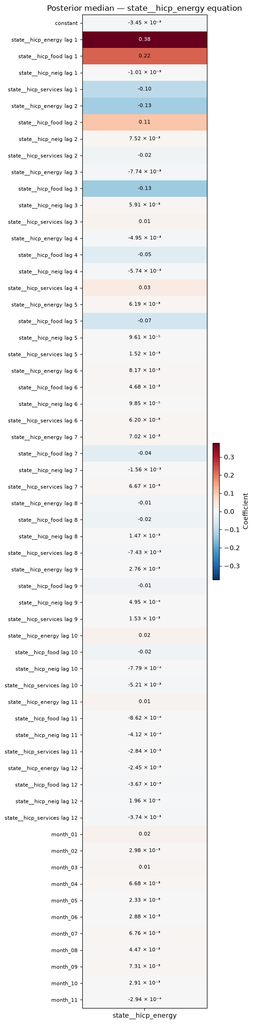

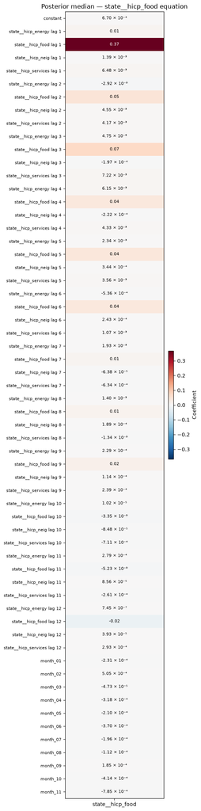

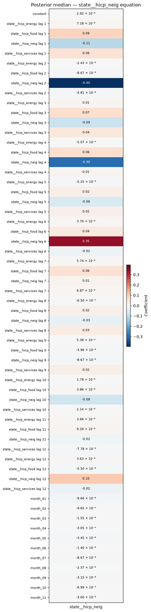

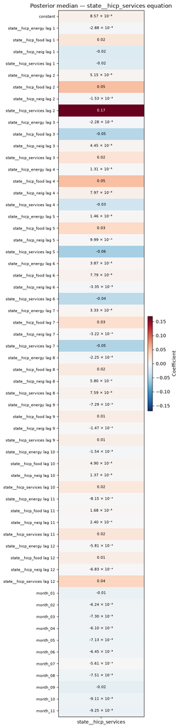

```python
coef = coefficient_posterior_table(result_12)
display(style_numeric_table(coef, caption="Headline joint BVAR(12) posterior coefficients"))

for equation in result_12["variables"]:
    fig = plot_coefficient_heatmap(result_12, equation=equation)
    display(fig)
    plt.close(fig)
```

## 9. Stochastic volatility, outliers and residual diagnostics

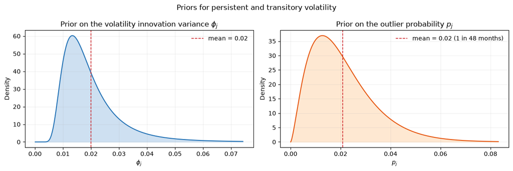

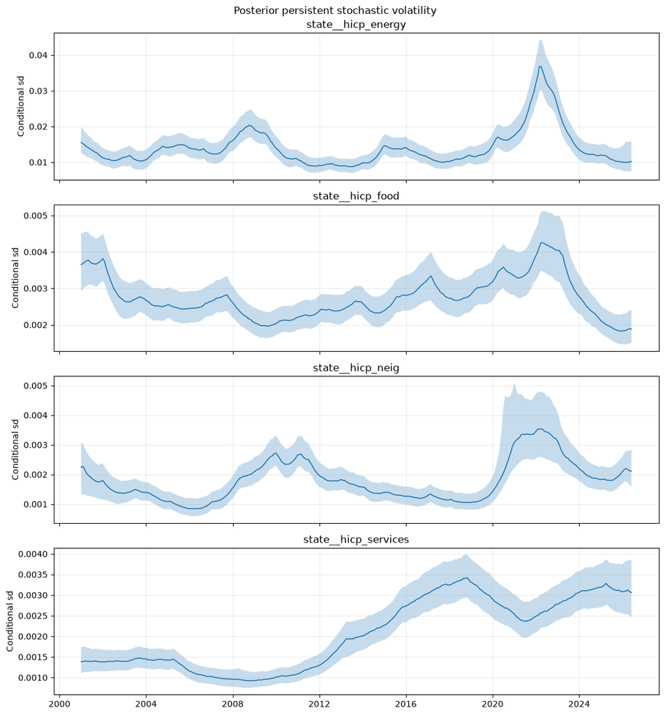

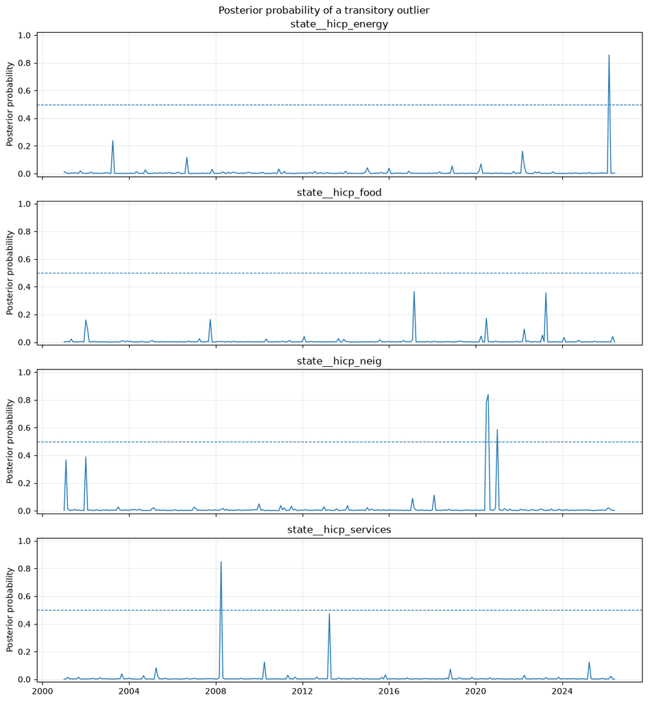

Standardised residual diagnostics

| variable | mean | sd | skewness | excess_kurtosis | acf_1 | maximum_absolute |
| --- | --- | --- | --- | --- | --- | --- |
| state__hicp_energy | -1.66 × 10⁻³ | 0.95 | -0.18 | 0.17 | 0.04 | 2.88 |
| state__hicp_food | 0.03 | 0.98 | -0.14 | 0.82 | -0.02 | 3.35 |
| state__hicp_neig | 0.03 | 0.92 | -0.18 | 0.18 | -0.08 | 3.14 |
| state__hicp_services | -0.02 | 0.95 | -0.28 | 0.51 | -0.04 | 3.60 |

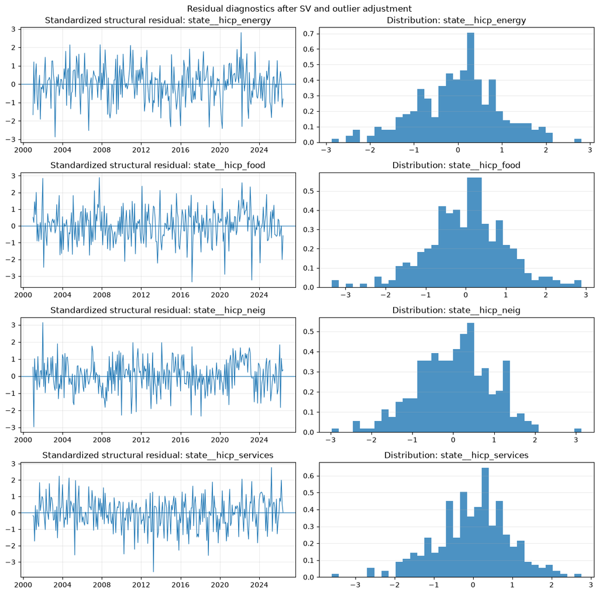

```python
fig = plot_phi_and_outlier_priors(result_12["prior"])
display(fig)
plt.close(fig)

fig = plot_posterior_volatility(result_12, include_outliers=False)
display(fig)
plt.close(fig)

fig = plot_outlier_probabilities(result_12)
display(fig)
plt.close(fig)

residual_diag = residual_diagnostic_table(result_12)
display(style_numeric_table(residual_diag, caption="Standardised residual diagnostics"))

fig = plot_standardized_residuals(result_12)
display(fig)
plt.close(fig)
```

## 10. Joint component forecast

```python
component_forecast = forecast_headline_joint_bvar(
    result_12,
    native_levels=native_levels,
    H=FORECAST_HORIZON,
    n_draws=min(FORECAST_DRAWS, result_12["n_draws"]),
    simulate_future_outliers=True,
    seed=2026,
)

print("Tail length:", component_forecast["tail_length"])
print("Future dates:", component_forecast["future_dates"][0], "→", component_forecast["future_dates"][-1])

print("Component HICP levels")
display(headline_component_forecast_table(component_forecast, kind="level"))

print("Component YoY inflation")
display(headline_component_forecast_table(component_forecast, kind="yoy"))
```

```
Tail length: 1
Future dates: 2026-08-01 00:00:00 → 2028-01-01 00:00:00
Component HICP levels
```

| months_ahead | variable | target_date | q05 | q16 | q50 | q84 | q95 |
| --- | --- | --- | --- | --- | --- | --- | --- |
| 1 | hicp_energy | 2026-08-01 | 108.343221 | 109.609522 | 110.917816 | 112.316662 | 113.535999 |
|  | hicp_food | 2026-08-01 | 100.786442 | 101.050731 | 101.398579 | 101.754567 | 102.014557 |
|  | hicp_neig | 2026-08-01 | 99.117202 | 99.316268 | 99.550121 | 99.784785 | 100.015233 |
|  | hicp_services | 2026-08-01 | 104.467309 | 104.685098 | 105.014993 | 105.313136 | 105.554921 |
| 3 | hicp_energy | 2026-10-01 | 106.271666 | 108.963306 | 111.903195 | 115.461569 | 118.206134 |
|  | hicp_food | 2026-10-01 | 100.648917 | 101.076886 | 101.688002 | 102.290896 | 102.799332 |
|  | hicp_neig | 2026-10-01 | 101.340334 | 101.612978 | 101.960491 | 102.330321 | 102.664743 |
|  | hicp_services | 2026-10-01 | 103.098581 | 103.613945 | 104.205367 | 104.794661 | 105.292302 |
| 6 | hicp_energy | 2027-01-01 | 103.700884 | 108.077444 | 112.465556 | 117.494999 | 122.479027 |
|  | hicp_food | 2027-01-01 | 100.333138 | 101.133751 | 102.040922 | 103.051941 | 103.865835 |
|  | hicp_neig | 2027-01-01 | 98.541252 | 98.996504 | 99.403085 | 99.856329 | 100.320910 |
|  | hicp_services | 2027-01-01 | 102.539437 | 103.357000 | 104.238891 | 105.271699 | 106.117389 |
| 12 | hicp_energy | 2027-07-01 | 101.131712 | 107.559160 | 114.605522 | 122.461868 | 133.107324 |
|  | hicp_food | 2027-07-01 | 99.642142 | 101.390524 | 103.076708 | 104.830699 | 106.409515 |
|  | hicp_neig | 2027-07-01 | 98.288168 | 98.956967 | 99.717602 | 100.571803 | 101.396732 |
|  | hicp_services | 2027-07-01 | 104.222728 | 105.388381 | 106.890750 | 108.425931 | 109.823323 |
| 18 | hicp_energy | 2028-01-01 | 99.630187 | 107.188132 | 116.075270 | 126.343294 | 144.425488 |
|  | hicp_food | 2028-01-01 | 99.361341 | 101.551979 | 104.099895 | 106.781324 | 109.716941 |
|  | hicp_neig | 2028-01-01 | 97.859566 | 98.982913 | 100.029129 | 101.179360 | 102.438717 |
|  | hicp_services | 2028-01-01 | 103.121846 | 104.594093 | 106.678408 | 108.635827 | 110.751728 |

```
Component YoY inflation
```

| months_ahead | variable | target_date | q05 | q16 | q50 | q84 | q95 |
| --- | --- | --- | --- | --- | --- | --- | --- |
| 1 | hicp_energy | 2026-08-01 | 9.526103 | 10.806229 | 12.128807 | 13.542926 | 14.775575 |
|  | hicp_food | 2026-08-01 | 0.225181 | 0.487998 | 0.833909 | 1.187915 | 1.446457 |
|  | hicp_neig | 2026-08-01 | 0.606173 | 0.808230 | 1.045596 | 1.283785 | 1.517695 |
|  | hicp_services | 2026-08-01 | 2.650397 | 2.864398 | 3.188556 | 3.481513 | 3.719093 |
| 3 | hicp_energy | 2026-10-01 | 7.682304 | 10.409673 | 13.388586 | 16.994192 | 19.775189 |
|  | hicp_food | 2026-10-01 | -0.011010 | 0.414153 | 1.021261 | 1.620203 | 2.125305 |
|  | hicp_neig | 2026-10-01 | 0.128776 | 0.398160 | 0.741519 | 1.106927 | 1.437351 |
|  | hicp_services | 2026-10-01 | 2.087911 | 2.598222 | 3.183847 | 3.767364 | 4.260126 |
| 6 | hicp_energy | 2027-01-01 | 4.148724 | 8.544184 | 12.951246 | 18.002409 | 23.007961 |
|  | hicp_food | 2027-01-01 | -0.650423 | 0.142341 | 1.040620 | 2.041728 | 2.847643 |
|  | hicp_neig | 2027-01-01 | 0.072359 | 0.534684 | 0.947583 | 1.407870 | 1.879669 |
|  | hicp_services | 2027-01-01 | 2.008991 | 2.822324 | 3.699653 | 4.727118 | 5.568433 |
| 12 | hicp_energy | 2027-07-01 | -7.684425 | -1.817289 | 4.614807 | 11.786278 | 21.503719 |
|  | hicp_food | 2027-07-01 | -1.474746 | 0.235705 | 1.806042 | 3.541896 | 5.106983 |
|  | hicp_neig | 2027-07-01 | -0.889213 | -0.214816 | 0.552185 | 1.413535 | 2.245369 |
|  | hicp_services | 2027-07-01 | -0.560321 | 0.551838 | 1.985259 | 3.449986 | 4.783249 |
| 18 | hicp_energy | 2028-01-01 | -9.769062 | -3.162870 | 3.182669 | 10.613500 | 20.899456 |
|  | hicp_food | 2028-01-01 | -1.755552 | -0.008259 | 2.008245 | 4.120523 | 6.191538 |
|  | hicp_neig | 2028-01-01 | -1.045201 | -0.225642 | 0.641739 | 1.540694 | 2.614564 |
|  | hicp_services | 2028-01-01 | -0.402617 | 0.803205 | 2.331962 | 3.865249 | 5.060186 |

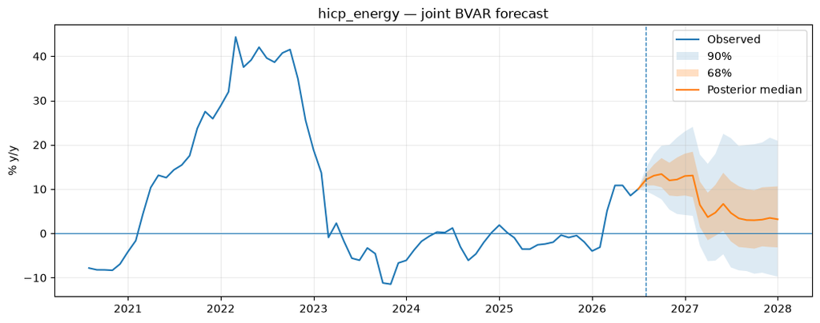

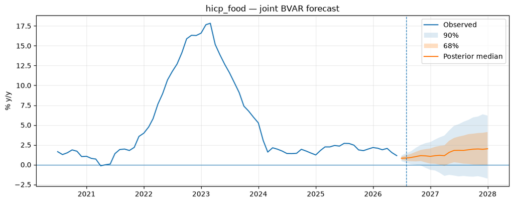

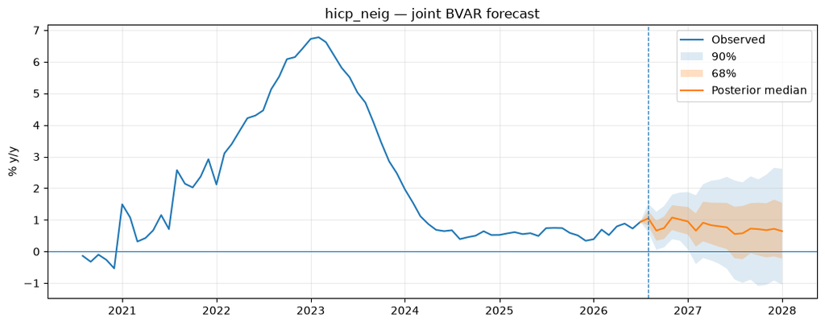

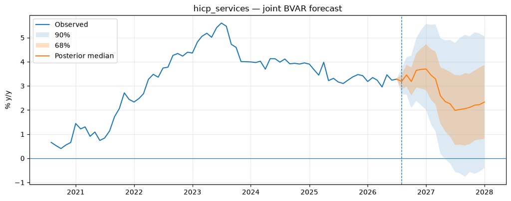

```python
figures = plot_joint_component_forecast_fans(
    component_forecast,
    kind="yoy",
    history=native_levels,
    last_obs=72,
)
for fig in figures.values():
    display(fig)
    plt.close(fig)
```

Each posterior draw contains Energy, Food, NEIG and Services jointly. Therefore draw number (d) is already one coherent four-component BVAR draw; there is no cross-model posterior-pairing problem.

## 11. Draw-by-draw Headline aggregation

```python
headline_forecast = aggregate_headline_draws(
    component_forecast,
    native_levels=native_levels,
    weights=weights,
    official_total=official_total,
    future_weight_policy="carry_forward_latest",
)

print(
    "Max draw-wise contribution additivity error:",
    headline_forecast["headline_drawwise_additivity_max_abs_error"],
)

print("Headline HICP index")
display(headline_forecast_table(headline_forecast, kind="level"))

print("Headline YoY inflation")
display(headline_forecast_table(headline_forecast, kind="yoy"))
```

```
Max draw-wise contribution additivity error: 0.0
Headline HICP index
```

| months_ahead | target_date | q05 | q16 | q50 | q84 | q95 |
| --- | --- | --- | --- | --- | --- | --- |
| 1 | 2026-08-01 | 103.021248 | 103.214962 | 103.444638 | 103.691573 | 103.908870 |
| 3 | 2026-10-01 | 102.993400 | 103.351911 | 103.820629 | 104.335212 | 104.836786 |
| 6 | 2027-01-01 | 101.846866 | 102.574396 | 103.308712 | 104.099255 | 105.010091 |
| 12 | 2027-07-01 | 102.693744 | 103.763034 | 105.021587 | 106.388350 | 107.919938 |
| 18 | 2028-01-01 | 102.081309 | 103.585854 | 105.302073 | 107.374134 | 109.450090 |

```
Headline YoY inflation
```

| months_ahead | target_date | q05 | q16 | q50 | q84 | q95 |
| --- | --- | --- | --- | --- | --- | --- |
| 1 | 2026-08-01 | 2.580153 | 2.773037 | 3.001730 | 3.247609 | 3.463975 |
| 3 | 2026-10-01 | 2.236848 | 2.592724 | 3.058000 | 3.568803 | 4.066693 |
| 6 | 2027-01-01 | 1.775623 | 2.502644 | 3.236446 | 4.026436 | 4.936635 |
| 12 | 2027-07-01 | -0.388552 | 0.663177 | 1.859851 | 3.202910 | 4.686298 |
| 18 | 2028-01-01 | -0.504015 | 0.664735 | 1.880036 | 3.395892 | 5.037872 |

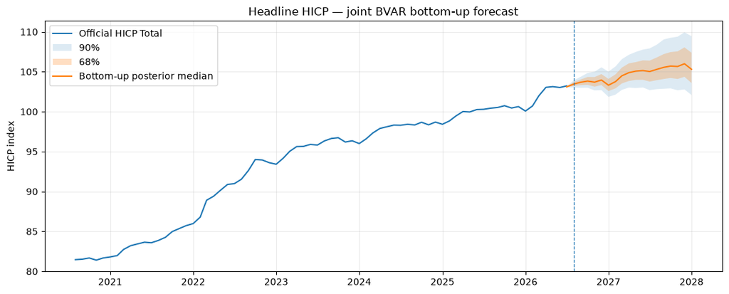

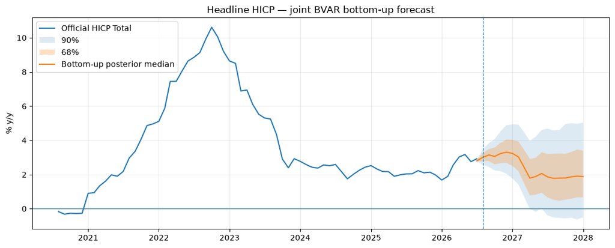

```python
fig = plot_headline_aggregate_forecast(
    headline_forecast,
    official_total,
    kind="level",
)
display(fig)
plt.close(fig)

fig = plot_headline_aggregate_forecast(
    headline_forecast,
    official_total,
    kind="yoy",
)
display(fig)
plt.close(fig)
```

The annual-weight policy is explicit:

- use the published weight vector for year (y) when available;
- if the forecast horizon enters a future year whose weights are not yet published, carry forward the latest complete published vector;
- never backfill a historical weight gap.

The aggregation is performed on component **index paths**, not on weighted inflation rates.

## 12. MCMC and stability diagnostics

MCMC diagnostics

|  | posterior_mean | posterior_sd | ESS | MCSE_mean | MCSE_over_sd |
| --- | --- | --- | --- | --- | --- |
| log likelihood | 5250.26 | 21.63 | 62.15 | 2.74 | 0.13 |
| spectral radius | 0.98 | 4.52 × 10⁻³ | 129.15 | 3.98 × 10⁻⁴ | 0.09 |
| A[state__hicp_food,state__hicp_energy] | -0.01 | 0.01 | 837.70 | 3.85 × 10⁻⁴ | 0.03 |
| phi[state__hicp_energy] | 0.04 | 0.02 | 70.52 | 2.44 × 10⁻³ | 0.12 |
| p_outlier[state__hicp_energy] | 0.01 | 6.85 × 10⁻³ | 825.45 | 2.39 × 10⁻⁴ | 0.03 |
| own L1[state__hicp_energy] | 0.38 | 0.06 | 1808.22 | 1.31 × 10⁻³ | 0.02 |
| phi[state__hicp_food] | 0.02 | 9.79 × 10⁻³ | 32.01 | 1.73 × 10⁻³ | 0.18 |
| p_outlier[state__hicp_food] | 0.01 | 7.26 × 10⁻³ | 395.12 | 3.65 × 10⁻⁴ | 0.05 |
| own L1[state__hicp_food] | 0.37 | 0.06 | 673.45 | 2.37 × 10⁻³ | 0.04 |
| phi[state__hicp_neig] | 0.05 | 0.03 | 22.92 | 5.93 × 10⁻³ | 0.21 |
| p_outlier[state__hicp_neig] | 0.02 | 8.56 × 10⁻³ | 108.62 | 8.21 × 10⁻⁴ | 0.10 |
| own L1[state__hicp_neig] | -0.11 | 0.04 | 456.19 | 1.97 × 10⁻³ | 0.05 |
| phi[state__hicp_services] | 0.02 | 5.47 × 10⁻³ | 119.74 | 5.00 × 10⁻⁴ | 0.09 |
| p_outlier[state__hicp_services] | 0.01 | 6.86 × 10⁻³ | 540.06 | 2.95 × 10⁻⁴ | 0.04 |
| own L1[state__hicp_services] | -0.02 | 0.05 | 1638.69 | 1.34 × 10⁻³ | 0.02 |

|  | value |
| --- | --- |
| retained_draws | 3000.000000 |
| median_spectral_radius | 0.976801 |
| q95_spectral_radius | 0.983414 |
| maximum_spectral_radius | 0.990901 |
| retained_unstable_share | 0.000000 |
| B_total_proposals | 6000.000000 |
| B_unstable_proposals | 0.000000 |
| B_instability_rejection_rate | 0.000000 |

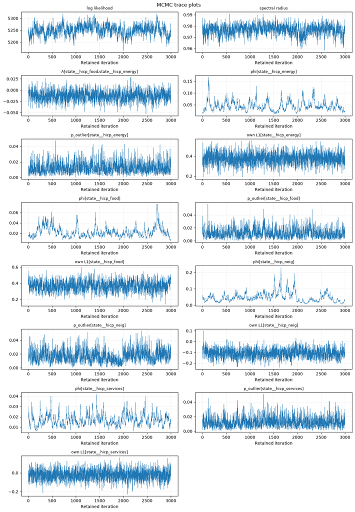

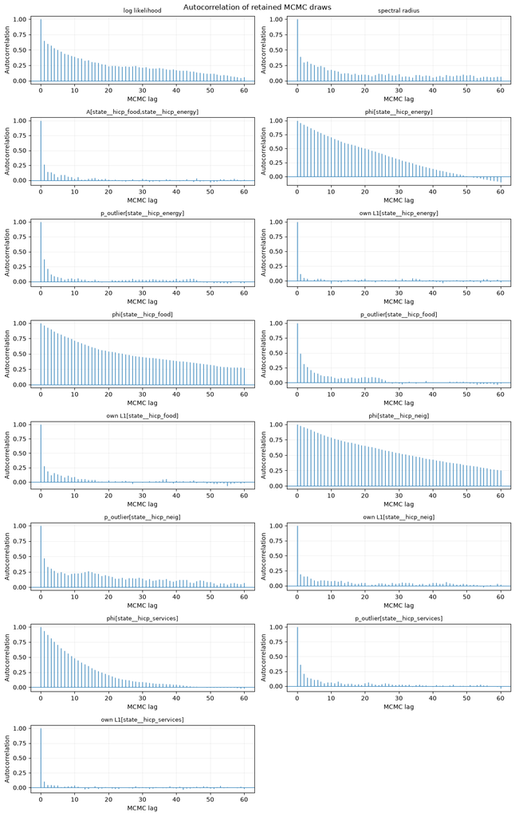

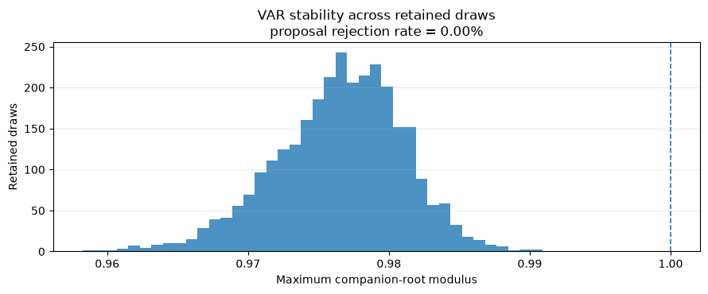

```python
display(style_numeric_table(mcmc_diagnostics(result_12), caption="MCMC diagnostics"))
display(stability_diagnostics(result_12).to_frame("value"))

fig = plot_trace_grid(result_12)
display(fig)
plt.close(fig)

fig = plot_chain_acf_grid(result_12)
display(fig)
plt.close(fig)

fig = plot_spectral_radius(result_12)
display(fig)
plt.close(fig)
```